# P4 - Alimentos básicos Latinoamericanos

3/8/2021

### **Titulo principal:**

Análisis de la evolución de los precios de los alimentos de primera necesidad en Latinoamérica (2000 - 2021)

### **Introducción:**

En los últimos 20 años, los países de la región han experimentado diferentes tipos de gobiernos y políticas económicas, así como también pasado por crisis internas y globales. De este modo, es interesante analizar cómo el precio de los alimentos más esenciales ha sufrido variaciones considerables a través del tiempo.

### **Objetivo:**

De este modo, nuestro grupo se planteó la siguiente interrogante a resolver en este trabajo:

**► Identificar la evolución de productos de la canasta básica familiar durante los últimos años recolectados**

**► Contrastar la información en 6 países de Latinoamérica**

**► Determinar los años de mayor y menor costo de cada producto en la última década**

**► Existe correlación entre el precio del pan y el trigo**

**¿Es nuestro tema interesante?**

Sí. El análisis de la información escogida muestra al lector la variación de los precios de algunos productos de la canasta básica familiar en dólares por kilogramo para seis países de Latinoamérica, Esto nos servirá para contrastar cómo evolucionan los precios entre los diferentes países del estudio, también se podrá relacionar la variación de estos con el tipo de gobierno o situación económica que atravesaban dichos países.

**¿Es nuestro tema plausible?**

Nuestro tema nos permitirá describir el comportamiento de los precios de 5 productos, pan, papa, maíz, trigo y arroz, en el intervalo de tiempo de Ene-2000 a Mar 2021 para los países de Argentina, Bolivia, Brasil, Chile, Ecuador y Perú.

**¿Es nuestro tema específico?**

Sí. La base de datos maneja diferentes variables numéricas como categóricas dentro de un intervalo de tiempo y zona específicos.

**¿Es nuestro tema desconocido?**

Si. Las personas podrían identificar la variación de los precios en sus respectivos países a lo largo de la historia, sin embargo, al ser nuestro estudio desde el ene-2000 a mar-2021 y para seis países hace que la relación de estos sea algo nuevo.

### **Planificación:**

Debido a que nuestro tiempo es limitado, se necesita una organización clara para poder cumplir con las fechas de entrega establecidas:

Objetivos internos:

- Reunirnos 1-2 veces por semana para avanzar con el proyecto.
- No tener tardanzas en las entregas de los avances.
- Realizar preguntas al profesor en caso ocurriese un atasco.

### **Marco Teórico:**

**Población objetivo:** Los precios de todos los productos de primera necesidad en Latinoamérica entre los años 2000-2021.

**La base de datos:** Se utiliza una base de datos creada por la FAO (La Organización de las Naciones Unidas para la Alimentación y la Agricultura). Es así, que tenemos los datos de 6 países distintos (Perú, Bolivia, Chile, Ecuador, Brasil y Argentina) con productos en común.

#### **Variables**

Se presenta la tabla de descripción de las variables:

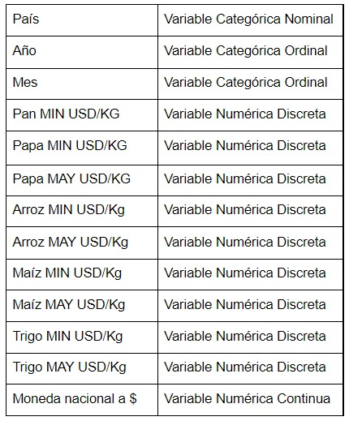

### ▲▼▲▼▲▼▲▼▲▼▲▼▲▼ Variables Numérica ▲▼▲▼▲▼▲▼▲▼▲▼

#### **Descriptores Numéricos:**

Precios minoristas USD/Kg

Precios mayoristas USD/Kg

[MODA] [Varianza, Desviación estándar y Rango Inter cuartil]

#### ** Precios minoristas USD/Kg **

**Precio del Pan USD/Kg**

```r
summary(DF$`Pan MIN USD/KG`)
```

```
##    Min. 1st Qu.  Median    Mean 3rd Qu.    Max.    NA's
##   0.280   1.380   1.840   1.831   2.180   4.410     159
```

**Precio de la Papa USD/Kg**

```
   Min. 1st Qu.  Median    Mean 3rd Qu.    Max.    NA's
 0.1800  0.4200  0.5200  0.6255  0.6900  2.4300     232
```

**Precio del Arroz USD/Kg**

```
   Min. 1st Qu.  Median    Mean 3rd Qu.    Max.    NA's
  0.340   0.890   1.060   1.085   1.260   1.920     196
```

**Precio del Maíz USD/Kg**

```
   Min. 1st Qu.  Median    Mean 3rd Qu.    Max.    NA's
  0.130   0.270   0.350   0.577   0.720   2.010     312
```

**Precio del Trigo USD/Kg**

```
   Min. 1st Qu.  Median    Mean 3rd Qu.    Max.    NA's
 0.2700  0.5600  0.8100  0.8299  1.0325  1.5600     158
```

#### **Precios mayoristas USD/Kg**

**Precio de la Papa USD/Kg**

```
   Min. 1st Qu.  Median    Mean 3rd Qu.    Max.    NA's
 0.0800  0.2900  0.4200  0.5235  0.5700  2.2000      98
```

**Precio del Arroz USD/Kg**

```
   Min. 1st Qu.  Median    Mean 3rd Qu.    Max.    NA's
  0.330   0.640   0.790   0.851   0.990   4.400     347
```

**Precio del Maíz USD/Kg**

```
   Min. 1st Qu.  Median    Mean 3rd Qu.    Max.    NA's
 0.0600  0.1700  0.2500  0.2568  0.3400  0.5700     411
```

**Precio del Trigo USD/Kg**

```
   Min. 1st Qu.  Median    Mean 3rd Qu.    Max.    NA's
 0.0800  0.2200  0.4800  0.4257  0.5700  1.1300     259
```

### ▲▼▲▼▲▼▲▼▲▼▲▼▲▼▲▼▲▼ Moda ▲▼▲▼▲▼▲▼▲▼▲▼▲▼▲▼▲

Entre el año 2000 hasta la actualidad, por lo general, los alimentos de estudio no superaron la media en su precio final tanto para la venta por menor cómo por mayor. Lo que nos indica que el actual incremento que se percibe es producto de diversos factores externos que priman en contra la economía. Como la inflación, crisis económicas, entre otros.

#### **Precios minoristas USD/Kg**

** Moda en el precio del Pan USD/Kg **

```r
library("modeest")
mfv(DF$`Pan MIN USD/KG`, na_rm = T)
```

```
## [1] 0.56
```

**Moda en el precio de la Papa USD/Kg**

```
[1] 0.44
```

**Moda en el precio del Arroz USD/Kg**

```
[1] 1.16
```

**Moda en el precio del Maíz USD/Kg**

```
[1] 0.32
```

**Moda en el precio del Trigo USD/Kg**

```
[1] 0.87
```

#### **Precios mayoristas USD/Kg**

**Moda en el precio de la Papa USD/Kg**

```
[1] 0.39
```

**Moda en el precio del Arroz USD/Kg**

```
[1] 0.64
```

**Moda en el precio del Maíz USD/KG**

```
[1] 0.19
```

**Moda en el precio del Trigo USD/KG**

```
[1] 0.22
```

### ▲▼▲▼▲▼▲▼▲▼▲▼▲▼▲ Varianza ▼▲▼▲▼▲▼▲▼▲▼▲▼▲▼▲▼

#### **Precios minoristas USD/Kg**

**Varianza del Precio del Pan USD/K**

```r
var(DF$`Pan MIN USD/KG`, na.rm = T)
```

```
## [1] 0.7364343
```

**Varianza del Precio de la Papa USD/Kg**

```
[1] 0.1338546
```

**Varianza del Precio del Arroz USD/Kg**

```
[1] 0.08664885
```

**Varianza del Precio del Maíz USD/Kg**

```
[1] 0.243804
```

**Varianza del Precio del Trigo USD/Kg**

```
[1] 0.09608687
```

#### **Precios mayoristas USD/Kg**

**Varianza del Precio de la Papa USD/Kg**

```
[1] 0.1605501
```

**Varianza del Precio del Arroz USD/Kg**

```
[1] 0.09585484
```

**Varianza del Precio del Maíz USD/Kg**

```
[1] 0.01078952
```

**Varianza del Precio del Trigo USD/Kg**

```
[1] 0.04512158
```

### ▲▼▲▼▲▼▲▼▲▼▲▼▲ Rango Inter cuartil ▼▲▼▲▼▲▼▲▼▲▼▲▼

#### **Precios minoristas USD/Kg**

**Rango Inter cuartil del Precio del Pan USD/Kg**

```r
x1 = quantile(DF$`Pan MIN USD/KG`,na.rm = T, 0.75)
x2= quantile(DF$`Pan MIN USD/KG`,na.rm = T, 0.25)
x1-x2
```

```
## 75%
## 0.8
```

**Rango intercuartil del Precio de la Papa USD/Kg**

```
 75%
0.27
```

**Rango intercuartil del Precio del Arroz USD/Kg**

```
 75%
0.37
```

**Rango intercuartil del Precio del Maíz USD/Kg**

```
 75%
0.45
```

**Rango intercuartil del Precio del Trigo USD/Kg**

```
   75%
0.4725
```

#### **Precios mayoristas USD/Kg**

**Rango intercuartil del Precio de la Papa USD/Kg**

```
 75%
0.28
```

**Rango intercuartil del Precio del Arroz USD/Kg**

```
 75%
0.35
```

**Rango intercuartil del Precio del Maíz USD/Kg**

```
 75%
0.17
```

**Rango intercuartil del Precio del Trigo USD/Kg**

```
 75%
0.35
```

### ▲▼▲▼▲▼▲▼▲▼▲▼▲ Desviación estándar ▼▲▼▲▼▲▼▲▼▲▼▲▼

#### **Precios minoristas USD/Kg**

**Desviación estándar del Precio del Pan USD/Kg**

```r
sd(DF$`Pan MIN USD/KG`, na.rm = T)
```

```
## [1] 0.8581575
```

**Desviación estándar del Precio de la Papa USD/Kg**

```
[1] 0.3658614
```

**Desviación estándar del Precio del Arroz USD/Kg**

```
[1] 0.2943618
```

**Desviación estándar del Precio del Maíz USD/Kg**

```
[1] 0.4937651
```

**Desviación estándar del Precio del Trigo USD/Kg**

```
[1] 0.3099788
```

#### **Precios mayoristas USD/Kg**

**Desviación estándar del Precio de la Papa USD/Kg**

```
[1] 0.400687
```

**Desviación estándar del Precio del Arroz USD/Kg**

```
[1] 0.3096043
```

**Desviación estándar del Precio del Maíz USD/Kg**

```
[1] 0.1038726
```

**Desviación estándar del Precio del Trigo USD/Kg**

```
[1] 0.2124184
```

### ▲▼▲▼▲▼▲▼▲▼▲ Coeficiente de Variación ▼▲▼▲▼▲▼▲▼▲▼

#### **Precios minoristas USD/Kg**

**Coeficiente de variación del Precio del Pan USD/Kg**

```r
sd(DF$`Pan MIN USD/KG`,na.rm = T) / mean(DF$`Pan MIN USD/KG`,na.rm = T)
```

```
## [1] 0.4686411
```

**Coeficiente de variación del Precio de la Papa USD/Kg**

```
[1] 0.5848848
```

**Coeficiente de variación del Precio del Arroz USD/Kg**

```
[1] 0.2712351
```

**Coeficiente de variación del Precio del Maíz USD/Kg**

```
[1] 0.8557323
```

**Coeficiente de variación del Precio del Trigo USD/Kg**

```
[1] 0.3735024
```

#### **Precios mayoristas USD/Kg**

**Coeficiente de variación del Precio de la Papa USD/Kg**

```
[1] 0.7654655
```

**Coeficiente de variación del Precio del Arroz USD/Kg**

```
[1] 0.3638325
```

**Coeficiente de variación del Precio del Maíz USD/Kg**

```
[1] 0.4044837
```

**Coeficiente de variación del Precio del Trigo USD/Kg**

```
[1] 0.4989572
```

### ▲▼▲▼▲▼▲▼▲▼▲▼▲▼ Lista de cotejo ▲▼▲▼▲▼▲▼▲▼▲▼

### **Lista de cotejo de precios mayoristas y minoristas**

Colocamos todos las datos obtenidos en una lista de cotejo para facilitar su visualización

[figure not shown]

### ▲▼▲▼▲▼▲▼▲▼▲ Gráfico descriptivo ▼▲▼▲▼▲▼▲▼▲▼▲

#### **Gráfica descriptiva**

Utilizaremos un histograma para representar gráficamente, la distribución de nuestros vectores de datos. Con la finalidad de obtener una vista previa de cómo se distribuyen cada uno de los diferentes vectores de datos.

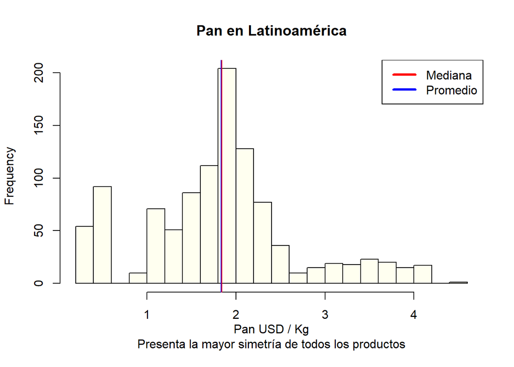

```r
hist(DF$`Pan MIN USD/KG`,breaks = 20,col = "ivory",main="Pan en Latinoamérica",xlab=("Pan USD / Kg
Presenta la mayor simetría de todos los productos"))
abline(v=c(median(DF$`Pan MIN USD/KG`,na.rm=T),mean(DF$`Pan MIN USD/KG`,na.rm=T)), col=c("red","blue") )
legend("topright",
       legend = c("Mediana", "Promedio"),
       lty = c(1, 1), col = c("red","blue"), lwd = 3)
```

#### **Gráfica descriptiva**

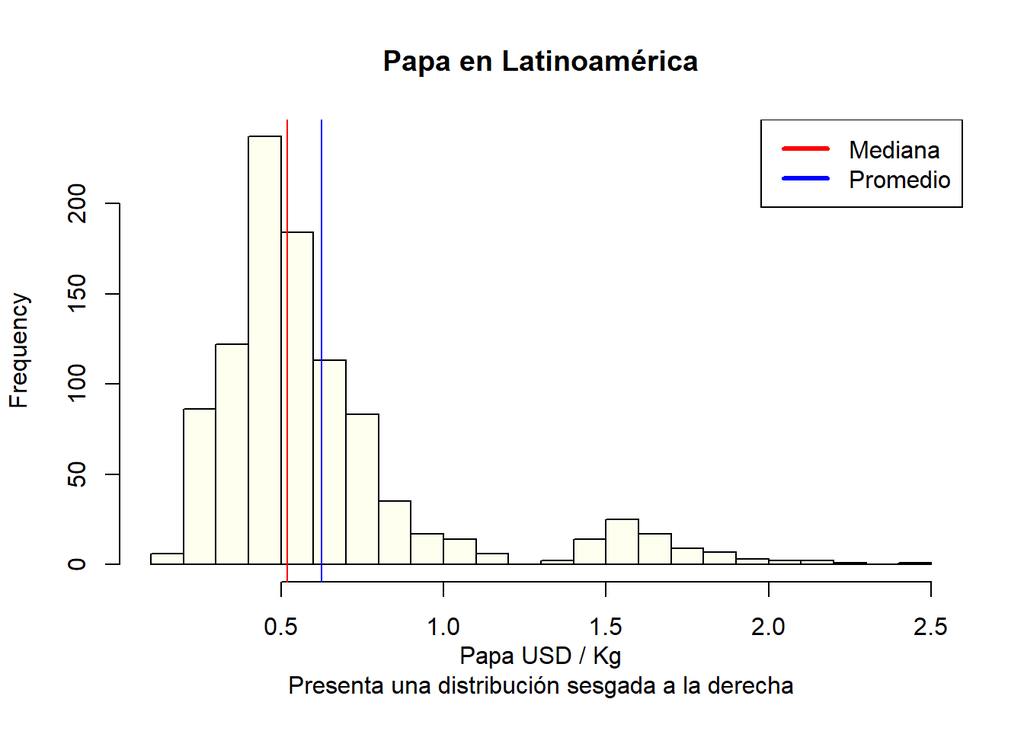

#### **Gráfica descriptiva**

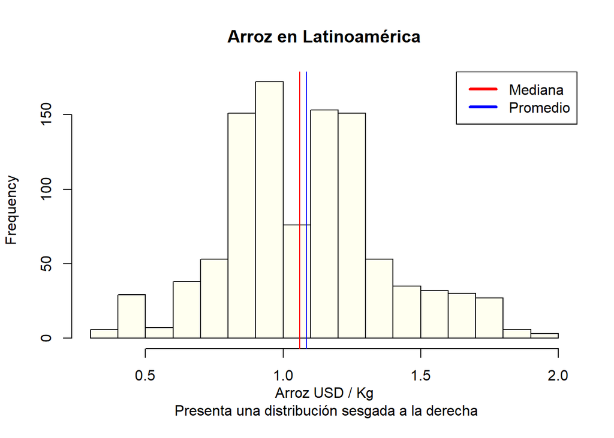

#### **Gráfica descriptiva**

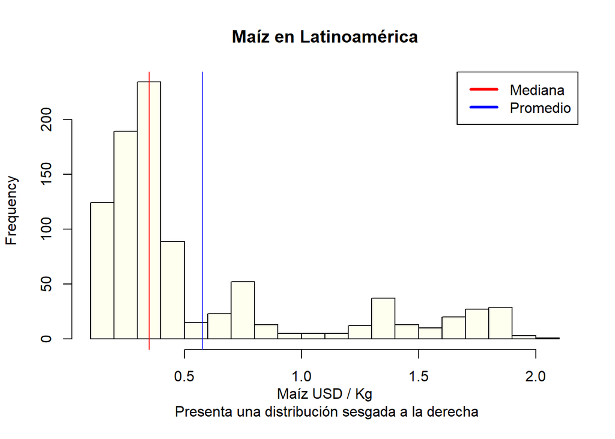

#### **Gráfica descriptiva**

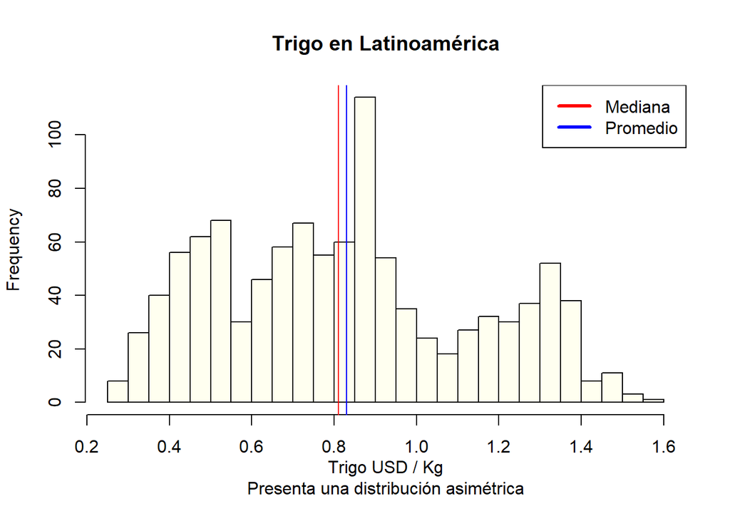

### ▲▼▲▼▲▼▲▼▲▼▲ Gráfico descriptivo ▼▲▼▲▼▲▼▲▼▲▼▲

#### **Gráfico descriptivo: Alcance de datos**

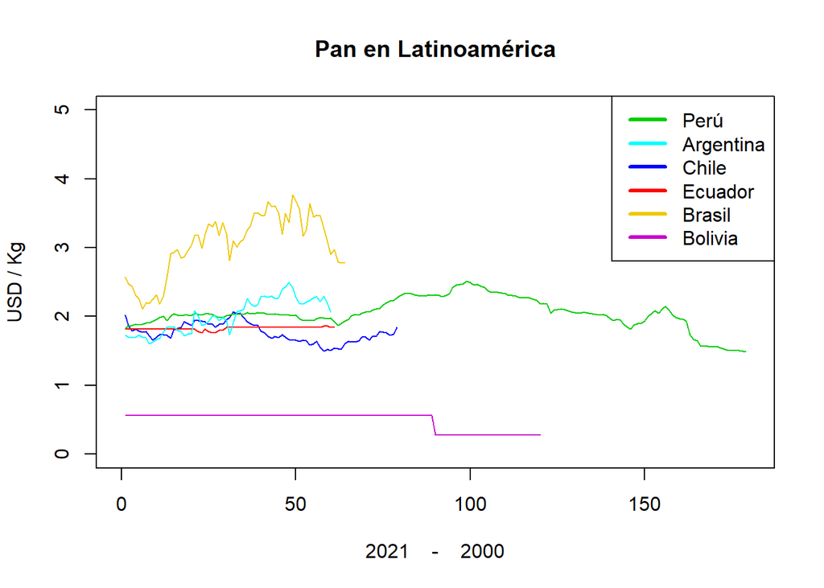

```r
plot(DFCH$`Pan MIN USD/KG`,ylim=c(0,5),xlim=c(0,180), main="Pan en Latinoamérica", col = "blue",xlab = "2021    -    2000",ylab ="USD / Kg",type = "l")
lines(DFEC$`Pan MIN USD/KG`, col = "red",xlab = "2021 - 2000",type = "l")
lines(DFBO$`Pan MIN USD/KG`, col = "magenta3",xlab = "2021 - 2000",type = "l")
lines(DFBR$`Pan MIN USD/KG`, col = "gold2",xlab = "2021 - 2000",type = "l")
lines(DFPE$`Pan MIN USD/KG`, col = "green3",xlab = "2021 - 2000",type = "l")
lines(DFAR$`Pan MIN USD/KG`, col = "cyan",xlab = "2021 - 2000",type = "l")
legend("topright",
       legend = c("Perú", "Argentina", "Chile" ,"Ecuador" ,"Brasil" ,"Bolivia"),
       lty = c(1, 1), col = c("green3","cyan","blue","red","gold2","magenta3"), lwd = 3)
```

Se observa que el Perú tiene un registro de datos de la variable pan mayor al resto de los países.

#### **Gráfico descriptivo: Alcance de datos**

Utilizando la función plot, podremos crear un gráfico lineal con varios vectores de datos, con la finalidad de observar su forma de distribución, su alcance, el contraste entre las mismas. Esto nos ayudará a delimitar el rango de estudio para obtener resultados más equiparables.

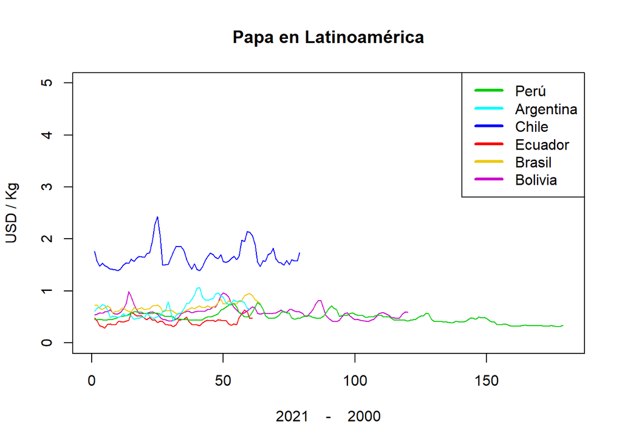

Se observa que el Perú contiene un registro de datos de la papa más amplio que los demás países.

#### **Gráfico descriptivo: Alcance de datos**

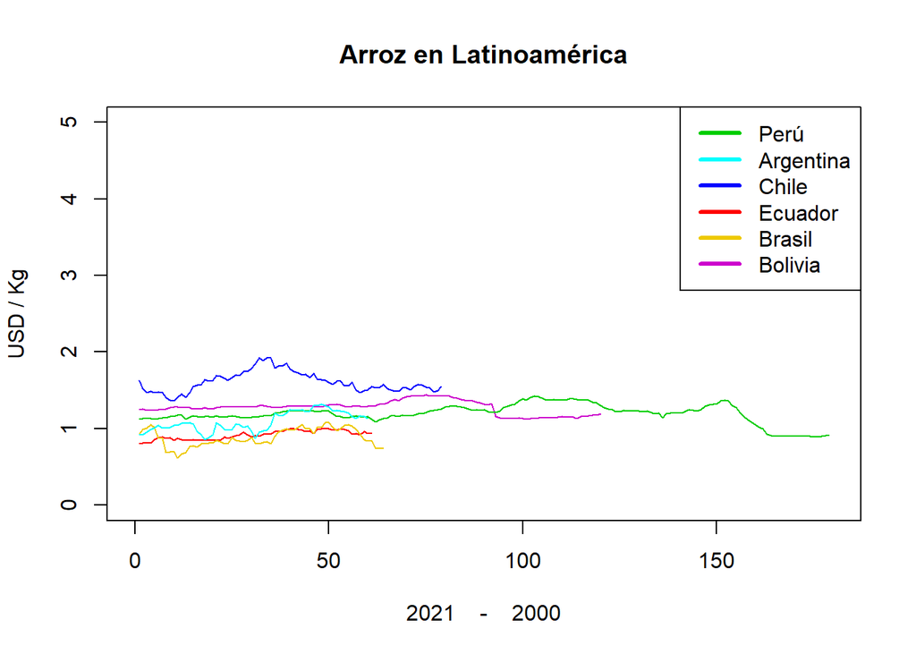

Se observa que el Perú contiene un registro de datos de arroz más amplio que los demás países.

#### **Gráfico descriptivo: Alcance de datos**

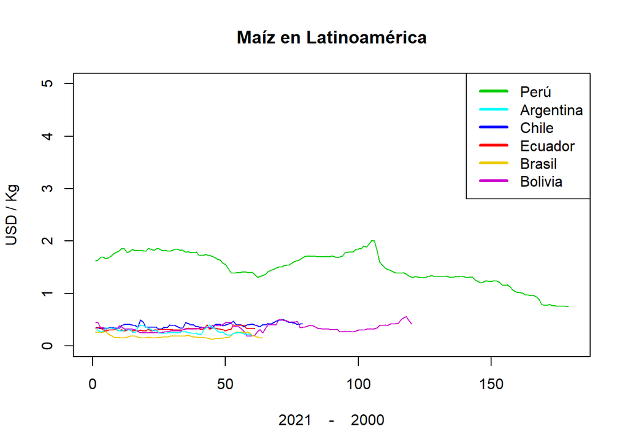

Se observa que el Perú contiene un registro de datos del maíz más amplio que los demás países.

#### **Gráfico descriptivo: Alcance de datos**

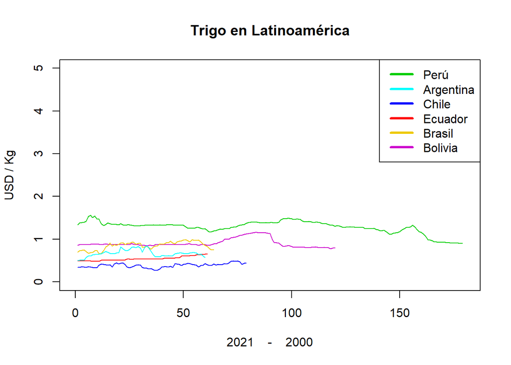

Se observa que el Perú contiene un registro de datos del trigo más amplio que los demás países.

Conclusión: Para análisis individual podremos trabajar con el vector completo y para un análisis grupal y comparativo podremos trabajar con un rango de datos equidistante.

### ▲▼▲▼▲▼▲▼▲▼▲ Gráfico descriptivo ▼▲▼▲▼▲▼▲▼▲▼▲

Utilizando el diagrama de caja y bigotes podremos representar gráficamente nuestros vectores de datos por medio de cuartales, medianas, valores atípicos, máximos y mínimos, con la finalidad de contrastar los vectores de datos de los productos y los países de este estudio.

#### **Gráfica descriptica de los vectores de datos**

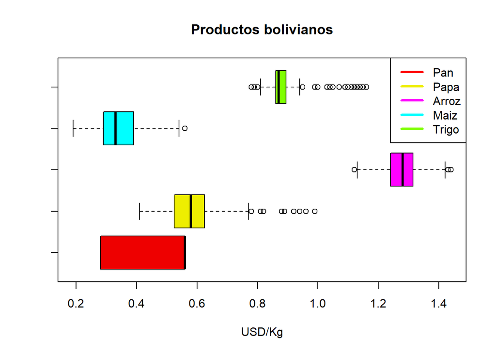

```r
boxplot(DFBO$`Pan MIN USD/KG`,DFBO$`Papa MIN USD/KG`,DFBO$`Arroz MIN USD/Kg`,DFBO$`Maiz MIN USD/Kg`,DFBO$`Trigo MIN USD/Kg`,horizontal = T,col=c("red2","yellow2","magenta","cyan","chartreuse") ,main="Productos bolivianos",xlab=("USD/Kg"))
legend("topright",
       legend = c("Pan", "Papa","Arroz","Maiz","Trigo"),
       lty = c(1, 1), col = c("red","yellow2","magenta","cyan","chartreuse"), lwd = 3)
```

La variable que presenta mayor dispersión es el pan; mientras que la menor, el trigo. La variable con mayor número de valores atípicos es el trigo.

#### **Patrón de productos por país: Gráfico descriptivo**

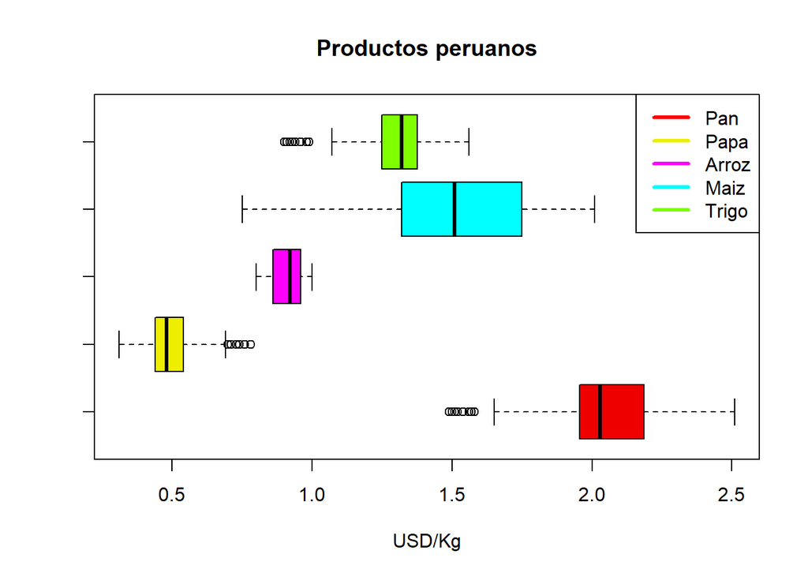

La variable que presenta mayor dispersión es el maíz; mientras que la menor dispersión, el arroz La variable con mayor número de valores atípicos son el trigo y el pan.

#### **Patrón de productos por país: Gráfico descriptivo**

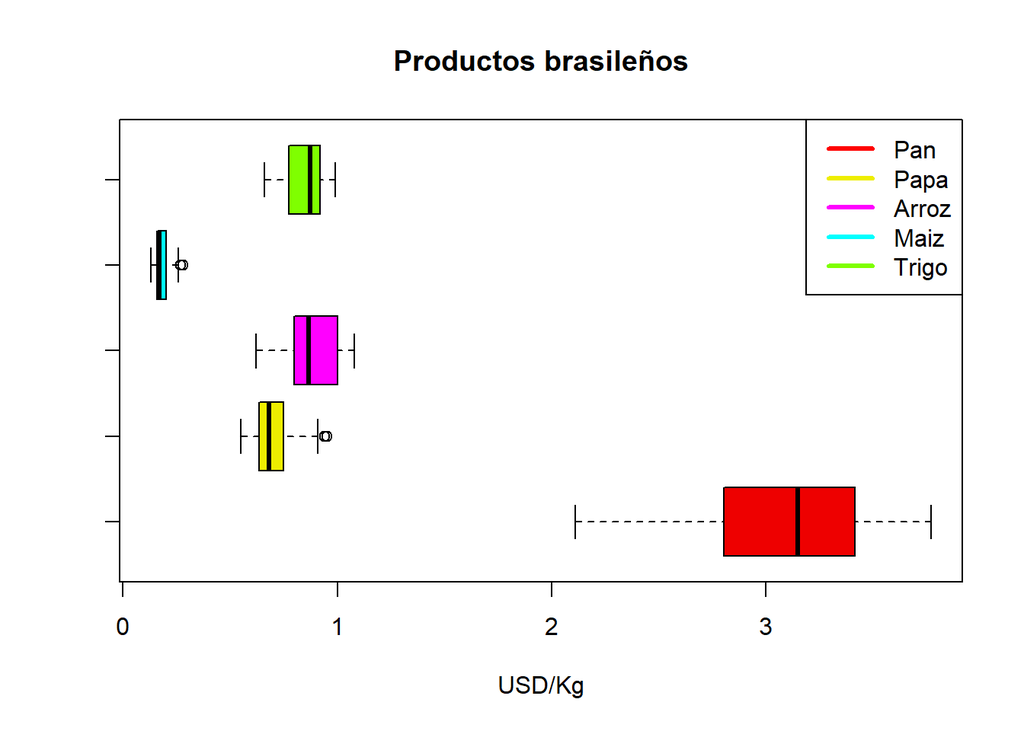

La variable que presenta mayor dispersión es el pan; mientras que la menor dispersión, el maíz La variable con mayor número de valores atípicos es la papa

#### **Patrón de productos por país: Gráfico descriptivo**

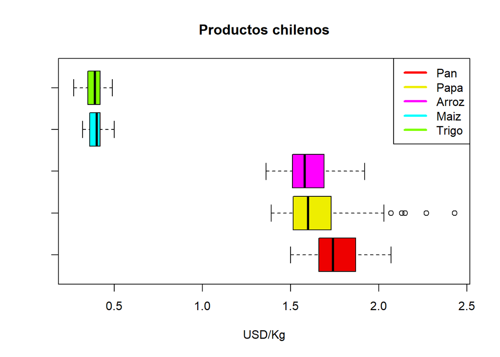

#### **Patrón de productos por país: Gráfico descriptivo**

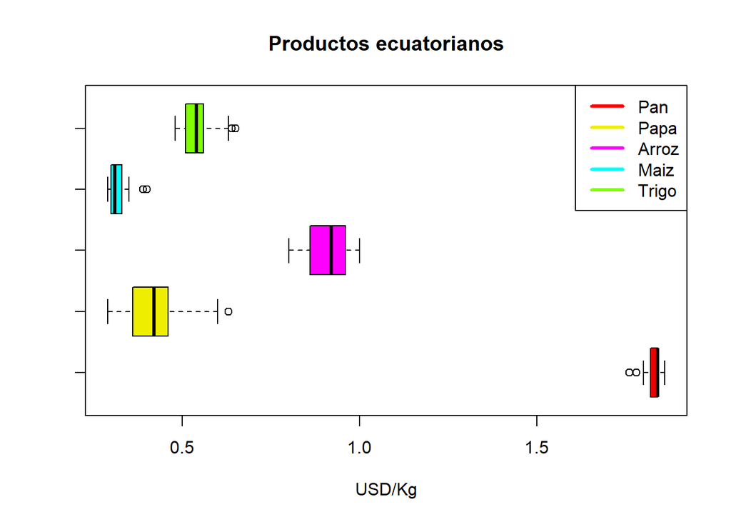

La variable que presenta mayor dispersión es la papa; mientras que la menor dispersión, el maíz. La variable con mayor número de valores atípicos es el trigo.

#### **Patrón de productos por país: Gráfico descriptivo**

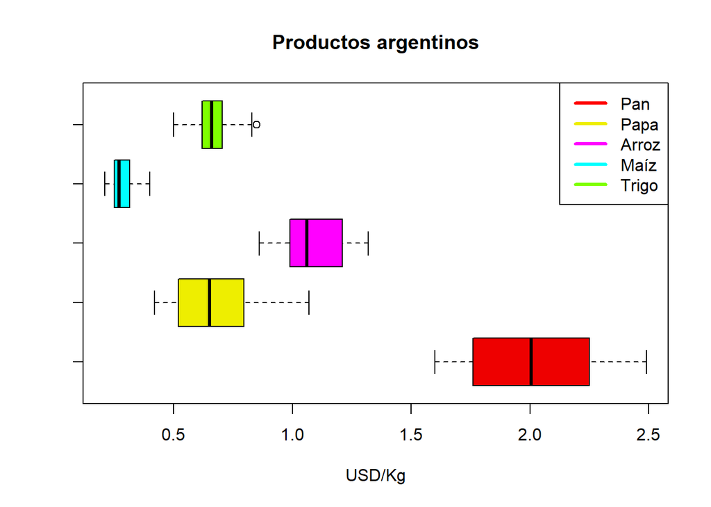

La variable que presenta mayor dispersión es el pan; mientras que la menor dispersión, el maíz. La variable con mayor número de valores atípicos es el trigo.

### ▲▼▲▼▲▼▲▼▲▼▲ Gráfico descriptivo ▼▲▼▲▼▲▼▲▼▲▼▲

#### **Patrón de un producto por países: Gráfico descriptivo**

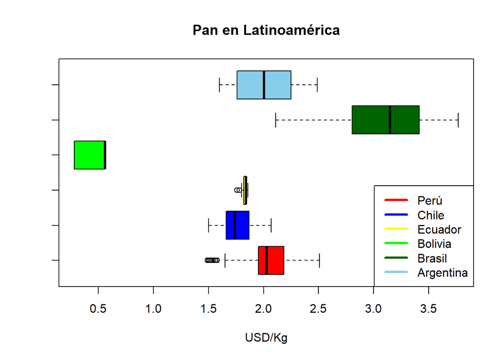

```r
boxplot(DFPE$`Pan MIN USD/KG`,DFCH$`Pan MIN USD/KG`,DFEC$`Pan MIN USD/KG`,DFBO$`Pan MIN USD/KG`,DFBR$`Pan MIN USD/KG`,DFAR$`Pan MIN USD/KG`,horizontal = T,col=c("red","blue","yellow","green","darkgreen","skyblue") ,main="Pan en Latinoamérica" ,xlab=("USD/Kg"))
legend("bottomright",
       legend = c("Perú", "Chile", "Ecuador", "Bolivia", "Brasil", "Argentina"),
       lty = c(1, 1), col = c("red","blue","yellow","green","darkgreen","skyblue"), lwd = 3)
```

#### **Patrón de un producto por países: Gráfico descriptivo**

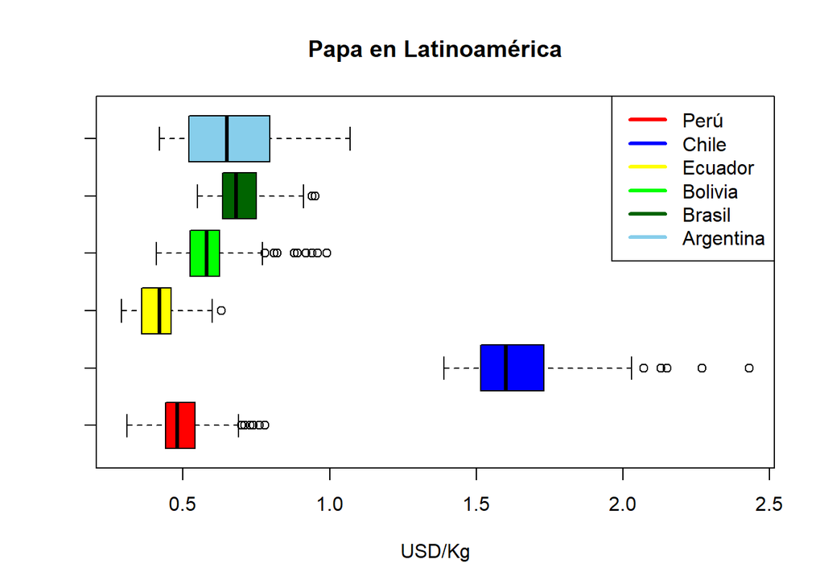

#### **Patrón de un producto por países: Gráfico descriptivo**

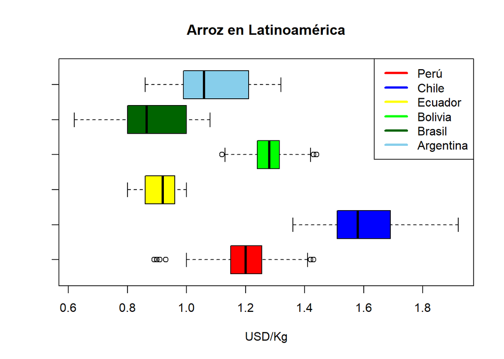

El país que ha presentado una mayor dispersión en sus precios es Argentina, al contrario de Bolivia. El país con más valores atípicos es Perú.

#### **Patrón de un producto por países: Gráfico descriptivo**

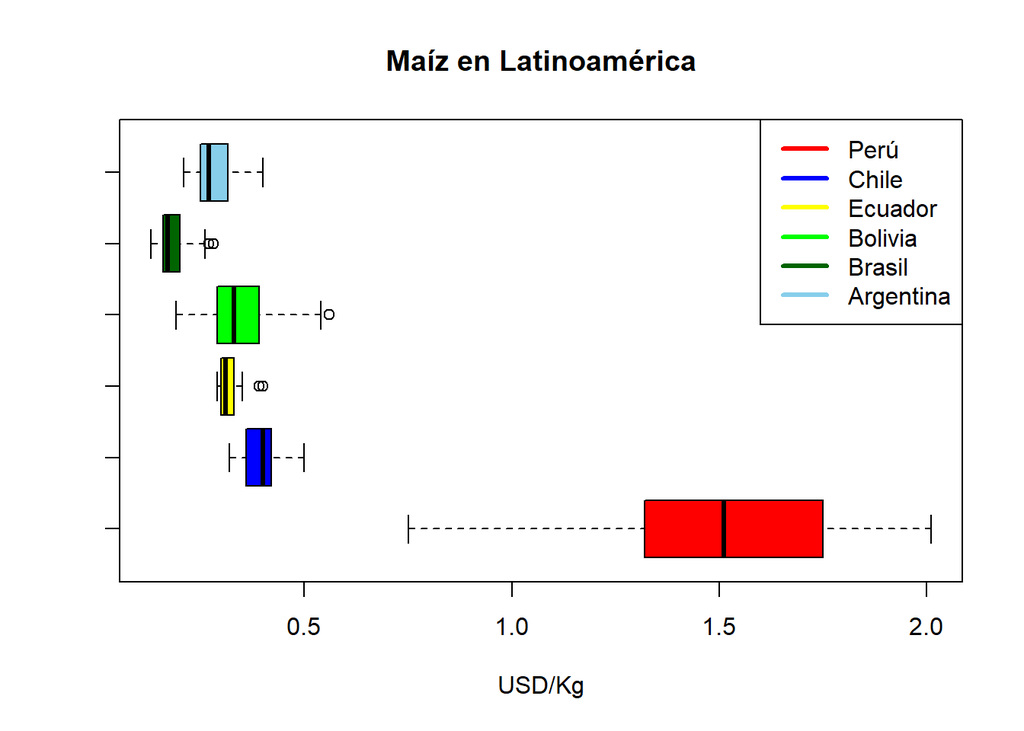

#### **Patrón de un producto por países: Gráfico descriptivo**

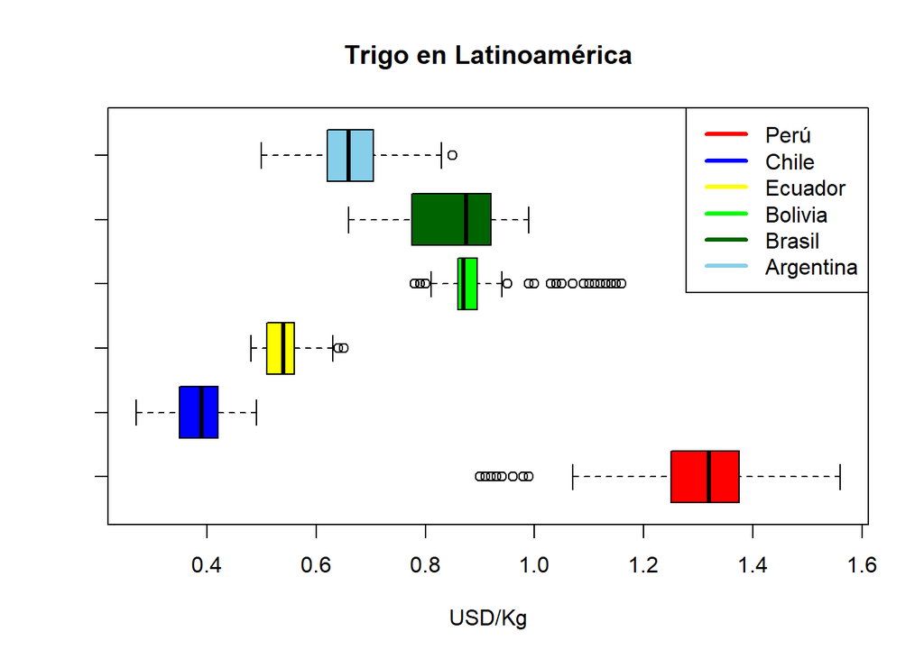

El país que ha presentado una mayor dispersión en sus precios es Brasil, al contrario de Bolivia. El país con más valores atípicos es Bolivia.

#### **Patrón de un producto por países: Gráfico descriptivo**

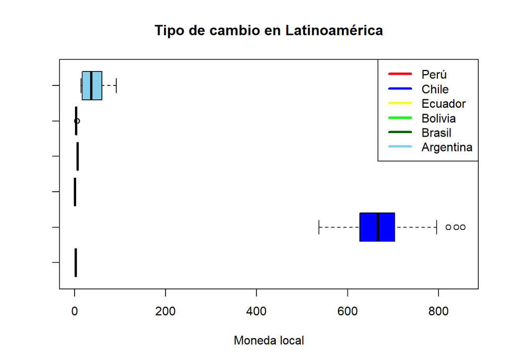

El país en el que más ha variado su unidad de cambio es Chile y en el que menos ha variado es Ecuador. El país con más valores atípicos es Chile.

### ▲▼▲▼▲▼▲▼▲▼▲ Gráfico descriptivo ▼▲▼▲▼▲▼▲▼▲▼▲

#### **Patrón producto vs Año: Gráfico descriptivo**

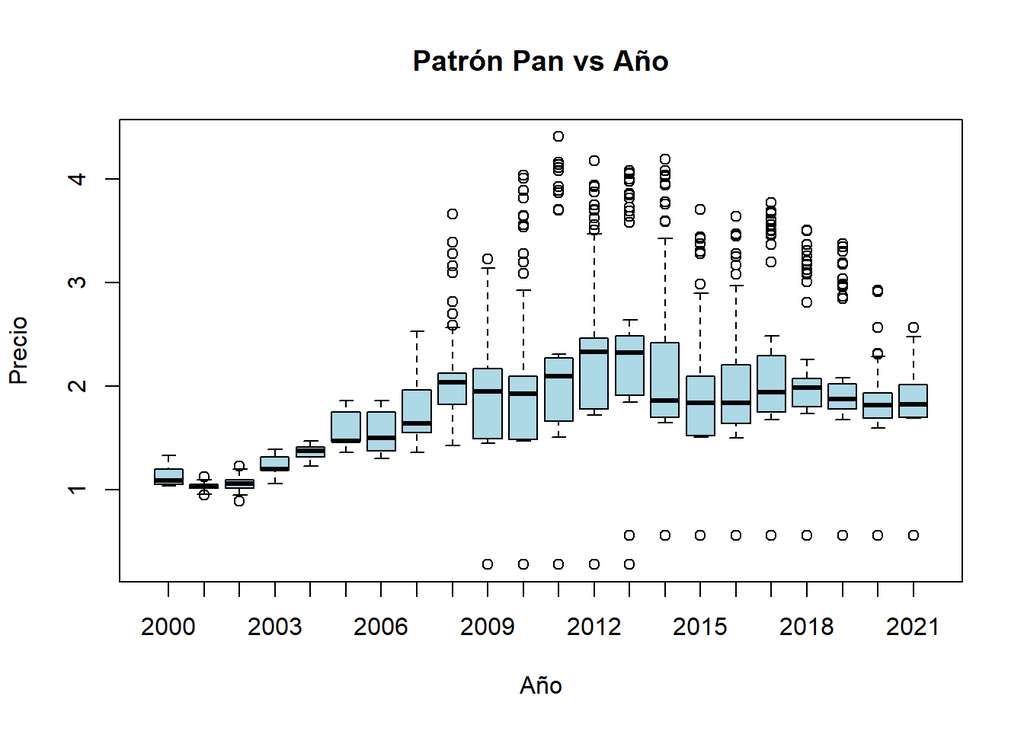

```r
boxplot(DF$`Pan MIN USD/KG`~ DF$Año, main="Patrón Pan vs Año", xlab="Año", ylab="Precio", col="light blue")
```

El año que ha presentado mayor variación en el precio del pan fue el 2012; mientras que, el que menos varió fue el 2002.

El valor más alto registrado fue en el 2011.

#### **Patrón producto vs Año: Gráfico descriptivo**

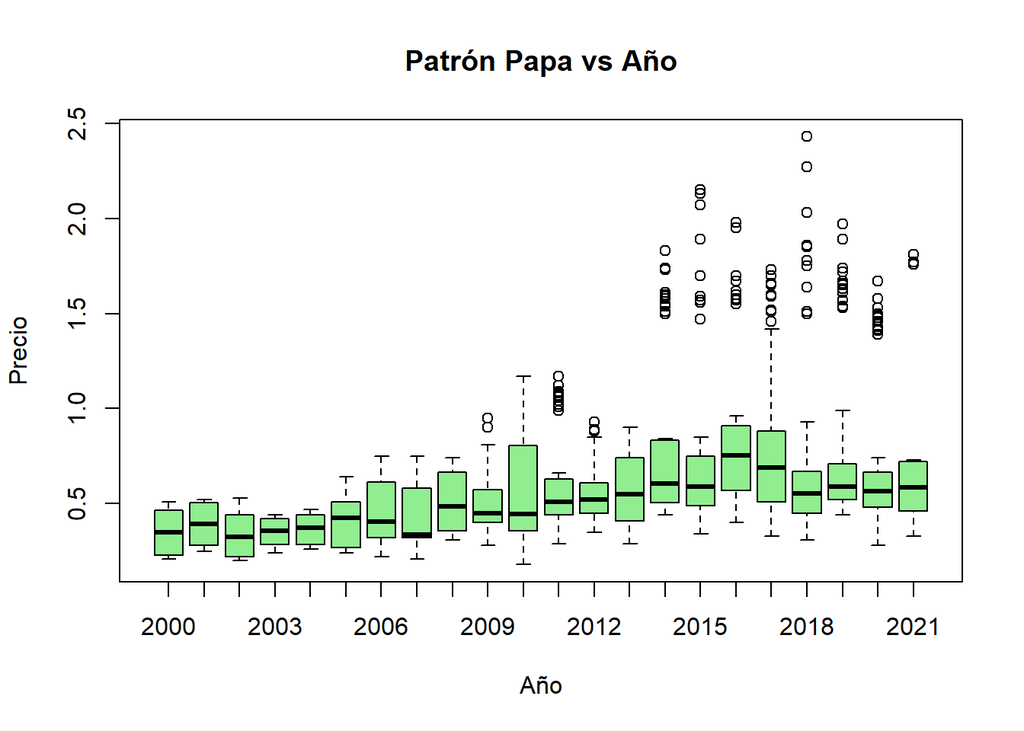

#### **Patrón producto vs Año: Gráfico descriptivo**

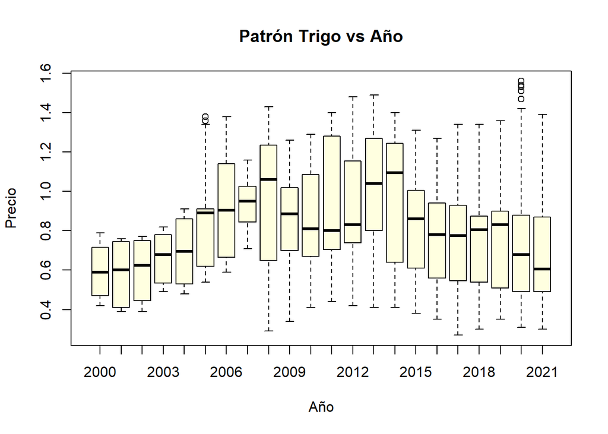

#### **Patrón producto vs Año: Gráfico descriptivo**

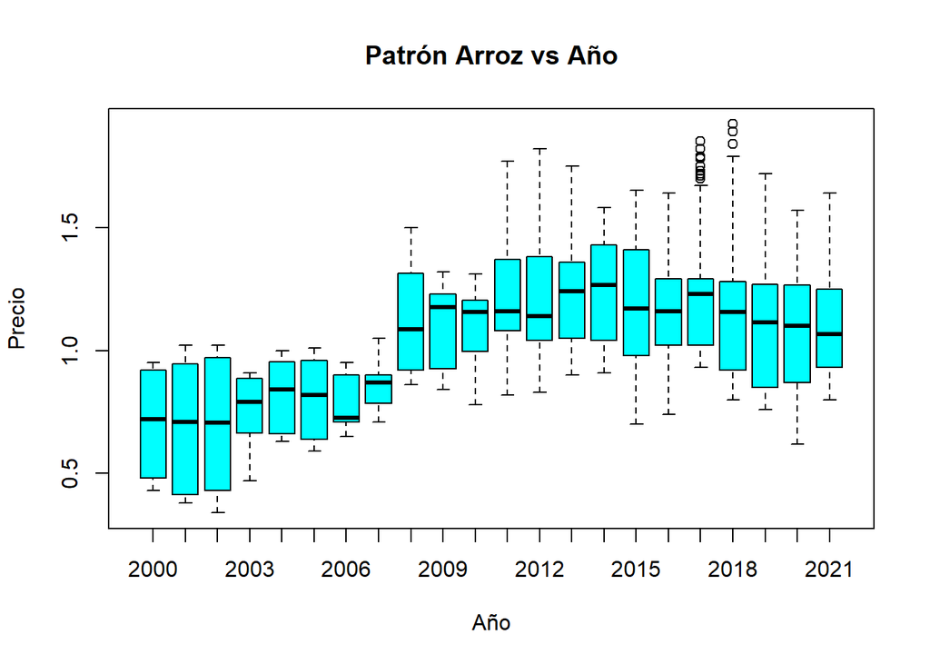

#### **Patrón producto vs Año: Gráfico descriptivo**

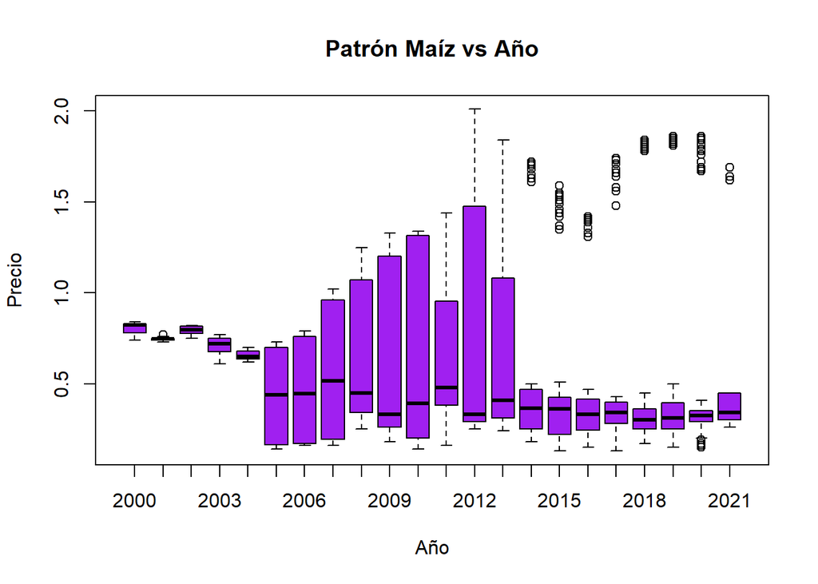

#### **Variables Categóricas: Gráfico descriptivo**

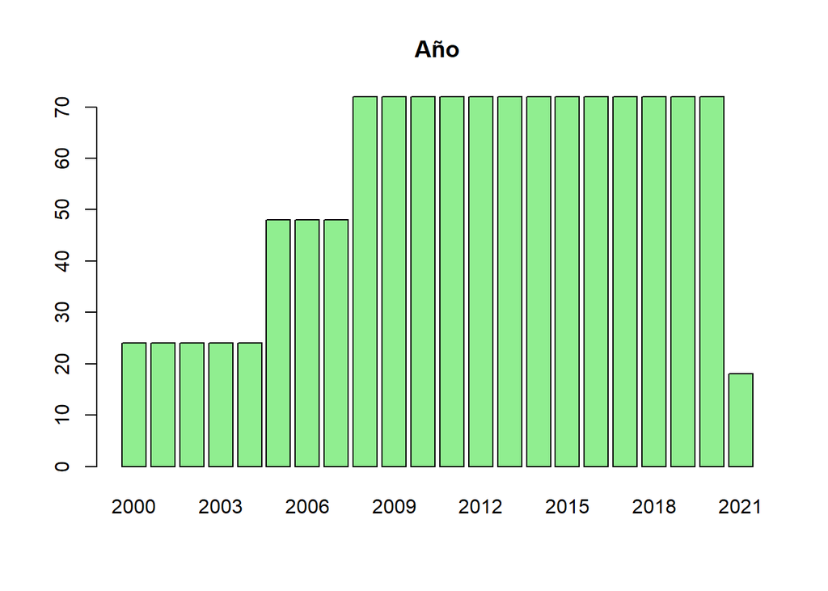

```r
barplot(table(DF$Año), col="light green", main="Año")
```

Se observa que nuestra base de datos contiene los datos completos desde el 2008 hasta la actualidad.

#### **Variables Categóricas: Gráfico descriptivo**

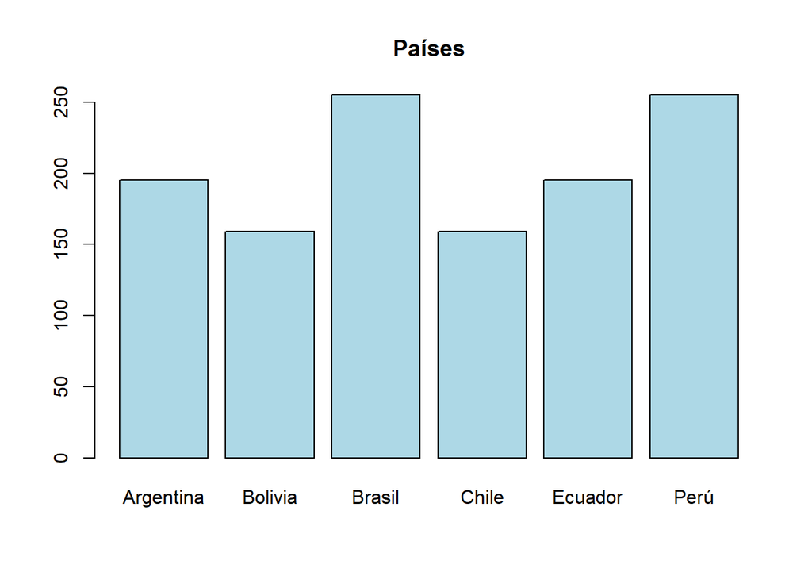

```r
barplot(table(DF$País), col="light blue", main="Países")
```

Se observa que Brasil y Perú tiene la mayor cantidad de datos completos